# portfolio optimisation using profit/loss data

kuldeep singh bhati

16 May 2016

# machine-learning-project using profit loss data for optimising portfolio

## Summary and goal of the project:

The project use ftse daily data, average and the profit/loss statement of strategy.

The goal of the project is to predict that do profit/loss history and market volatility can predict next profit/loss, so that we can increase stake, reduce stake or keep the current stake.

## Training and test data set

The training data used for the project is kept on git: https://github.com/kuldeepldec/portfolio-optimization-using-P-L

## Summary of raw training and testing data set and installing libraries for the project

```
## Version 0.4-0 included new data defaults. See ?getSymbols.
```

```r
ftse<-read.table("test.txt",header=TRUE,sep=" ",na.strings="NA")
```

So we are reading first our data which has ftse OHLC price with average and profit/Loss for that day.

If our profit is above 15 points I have given it UP and if loss is below -15, i have given DOWN. If the value is in between I have given it STAT

```r
class<-ifelse(ftse[,8]>15,"UP",ifelse(ftse[,8]<15 & ftse[,8]>-15,"STAT", "DOWN"))
```

Now remove date and time from ftse data

```r
ftse<-subset(ftse[,3:8])
```

Now identify that we were in uptrend or down trend when we hit with a profit/loss

```r
ymed<-Lag(Cl(ftse)-Op(ftse))
yrange<-Lag(Hi(ftse)-Lo(ftse))
Oc1=Op(ftse)-Lag(Cl(ftse))
Cc1<-Lag(Cl(ftse)-Lag(Cl(ftse)))
```

Taking average true range from atr for 5,10 and 20 days to know the voaltility in the market

```r
atr5<-ATR(HLC(ftse),5)
atr5<-atr5[,2]
atr5<-Lag(atr5)


atr10<-ATR(HLC(ftse),10)
atr10<-atr10[,2]
atr10<-Lag(atr10)


atr20<-ATR(HLC(ftse),20)
atr20<-atr20[,2]
atr20<-Lag(atr20)
```

trend is average subtraction from open

```r
trendo<-Op(ftse)-Lag(ftse[,5])
trendcl1<-Lag(Cl(ftse)-ftse[,5])
```

## create dataset from the above indicator

```r
dataset<-data.frame(ymed,yrange,Oc1,Cc1,atr5,atr10,atr20,trendo,trendcl1,ftse[,6],class)
```

cleaning all na from the data

```r
dataset<-na.omit(dataset)
```

Using last 5 profit/loss as input data

```r
profit1<-Lag(dataset[,10])
profit2<-Lag(dataset[,10],2)
profit3<-Lag(dataset[,10],3)
profit4<-Lag(dataset[,10],4)
profit5<-Lag(dataset[,10],5)
```

## Final dataset using previous P/L, volatility, market trend and class variable to predict

```r
newdataset<-data.frame(dataset[1:10],profit1,profit2,profit3,profit4,profit5,dataset[,11])
```

naming new columns and cleaning data

```r
colnames(newdataset)<-c("ymed","yrange","Oc1","Cc1","atr5","atr10","atr20","trendo","trendcl1","profit","profit1","profit2","profit3","profit4","profit5","class")

newdataset<-na.omit(newdataset)
```

## partition data for training and testing

```r
inTrain<-createDataPartition(y = newdataset$class, p = 0.8, list = FALSE)
training<-newdataset[inTrain,]
validation<-newdataset[-inTrain,]
```

removing profit data from training and testing

```r
ftraining<-training[,-10]
fvalidation<-validation[,-10]
profitTest<-validation[,10]
```

Preprocess the data. determine pre-processing parameters of prep input data normalized;

```r
preProc<- preProcess(ftraining[, -15], method = c("center", "scale","spatialSign"))
trainR<-predict(preProc,ftraining[,-15])
validR<-predict(preProc,fvalidation[,-15])
```

Now use random forest to train the model on training data using class variable

```r
set.seed(1)

modelFit<-randomForest(ftraining$class ~.,data=trainR,importance=TRUE)
```

predicting value on test data

```r
pf<-predict(modelFit,validR)
```

# Build our final data set with random forest alone

```r
FinalDataSet<-data.frame(seq(1,69,1),profitTest,pf)
```

# Double the position size of winning trades, halve losing trades and keep neutral trades the same

```r
WinningTrades<-ifelse(FinalDataSet[,3]=="UP",2*FinalDataSet[,2],0)
LosingTrades<-ifelse(FinalDataSet[,3]=="DOWN",.5*FinalDataSet[,2],0)
NeutralTrades<-ifelse(FinalDataSet[,3]=="STAT",FinalDataSet[,2],0)
```

# Combine our trades

```r
RF.Final.Trades<-WinningTrades+LosingTrades+NeutralTrades
```

# Calculate the random forest equity curve

```r
RF.Final.Equity<-cumsum(RF.Final.Trades)
print(RF.Final.Equity)
```

```
##  [1]  47.000  66.250 153.650 156.850 179.250 189.250 201.750 206.000
##  [9] 209.600 234.200 167.800 145.600 125.500 131.800 146.100 197.600
## [17] 315.600 400.200 287.200 372.200 366.200 368.135 397.835 432.305
## [25] 436.175 482.735 599.855 607.325 630.725 621.925 612.925 650.425
## [33] 638.225 634.025 625.325 558.825 582.625 592.925 613.925 596.725
## [41] 599.725 598.525 629.525 612.525 618.325 597.825 590.325 659.325
## [49] 659.925 598.925 531.925 546.925 605.525 590.025 624.025 565.725
## [57] 517.325 496.325 546.125 505.825 506.075 542.675 529.375 462.175
## [65] 435.375 437.375 407.575 414.375 454.475
```

# Calculate the original equity curve

```r
OriginalEquity<-cumsum(FinalDataSet[,2])
print(OriginalEquity)
```

```
##  [1]  23.50  62.00 105.70 108.90 120.10 130.10 142.60 151.10 158.30 207.50
## [11] 174.30 152.10 111.90 118.20 132.50 184.00 243.00 285.30 228.80 271.30
## [21] 268.30 272.17 301.87 336.34 340.21 386.77 445.33 452.80 476.20 471.80
## [31] 462.80 500.30 488.10 483.90 475.20 408.70 432.50 442.80 463.80 446.60
## [41] 449.60 448.40 479.40 462.40 468.20 447.70 440.20 474.70 475.00 444.50
## [51] 377.50 385.00 414.30 398.80 415.80 357.50 333.30 312.30 337.20 296.90
## [61] 297.40 334.00 320.70 253.50 240.10 241.10 226.20 233.00 273.10
```

# Create a data frame for data used to plot

```r
RF.Plot.Data<-data.frame(FinalDataSet[,1],RF.Final.Equity,OriginalEquity)
```

# Build our plots

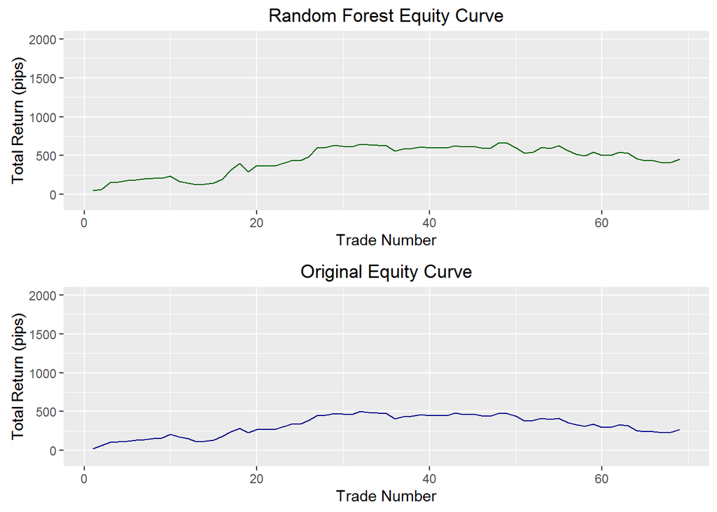

```r
RF.After.Equity<-ggplot(RF.Plot.Data,aes(x=RF.Plot.Data[,1],y=RF.Plot.Data[,2]))+geom_line(color="darkgreen")+labs(title="Random Forest Equity Curve",y="Total Return (pips)",x="Trade Number")+ylim(-100,2000)

RF.Before.Equity<-ggplot(RF.Plot.Data,aes(x=RF.Plot.Data[,1],y=RF.Plot.Data[,3]))+geom_line(color="darkblue")+labs(title="Original Equity Curve",y="Total Return (pips)",x="Trade Number")+ylim(-100,2000)
grid.arrange(RF.After.Equity,RF.Before.Equity,ncol=1,nrow=2)
```

## Let see we combine SVM and random forest to predict test data and see if we get improved result

```r
set.seed(2)
modelsvm<-svm(ftraining$class ~.,data=trainR,method="svmRadial")
pred1<-predict(modelFit,validR)
pred2<-predict(modelsvm,validR)
predDF<-data.frame(pred1,pred2,class=fvalidation$class)
combModFit<-train(class ~.,method="gam",data=predDF)
combpred<-predict(combModFit,predDF)
```

# Build our final data set with random forest and SVM

```r
CombFinalDataSet<-data.frame(seq(1,69,1),profitTest,combpred)
```

# Double the position size of winning trades, halve losing trades and keep neutral trades the same

```r
CombWinningTrades<-ifelse(CombFinalDataSet[,3]=="UP",2*CombFinalDataSet[,2],0)
CombLosingTrades<-ifelse(CombFinalDataSet[,3]=="DOWN",.5*CombFinalDataSet[,2],0)
CombNeutralTrades<-ifelse(CombFinalDataSet[,3]=="STAT",CombFinalDataSet[,2],0)
```

# Combine our trades

```r
Comb.Final.Trades<-CombWinningTrades+CombLosingTrades+CombNeutralTrades
```

# Calculate the random forest and SVM equity curve

```r
Comb.Final.Equity<-cumsum(Comb.Final.Trades)
print(Comb.Final.Equity)
```

```
##  [1]  23.50  62.00 105.70 108.90 120.10 130.10 142.60 151.10 158.30 207.50
## [11] 174.30 152.10 111.90 118.20 132.50 184.00 243.00 285.30 228.80 271.30
## [21] 268.30 272.17 301.87 336.34 340.21 386.77 445.33 452.80 476.20 471.80
## [31] 462.80 500.30 488.10 483.90 475.20 408.70 432.50 442.80 463.80 446.60
## [41] 449.60 448.40 479.40 462.40 468.20 447.70 440.20 474.70 475.00 444.50
## [51] 377.50 385.00 414.30 398.80 415.80 357.50 333.30 312.30 337.20 296.90
## [61] 297.40 334.00 320.70 253.50 240.10 241.10 226.20 233.00 273.10
```